# GOV 1006 Pset #4

Maria Burzillo

2/25/2020

# 1. A Linear Model using Age to Explain Income

The residual standard deviation is $74,288 with uncertainty as represented by mad sd. This indicates that income will be within $74,288 of the linear predcictor (mean value for the simulated data) for about 68% of the data points and will be within $\pm$ 2*$74,288 or $\pm$ $148,575 (two residual standard deviations) of the linear predictor approximately 95% of the time.

The R2 value of 0.0051 suggests that the model only explains 0.51% of the variance in the income level for these data. This makes sense because there are many likely more important factors in a person’s income such as education level, occupation type, or race. Below, we can visualize the model fit and the data on a simple scatter plot:

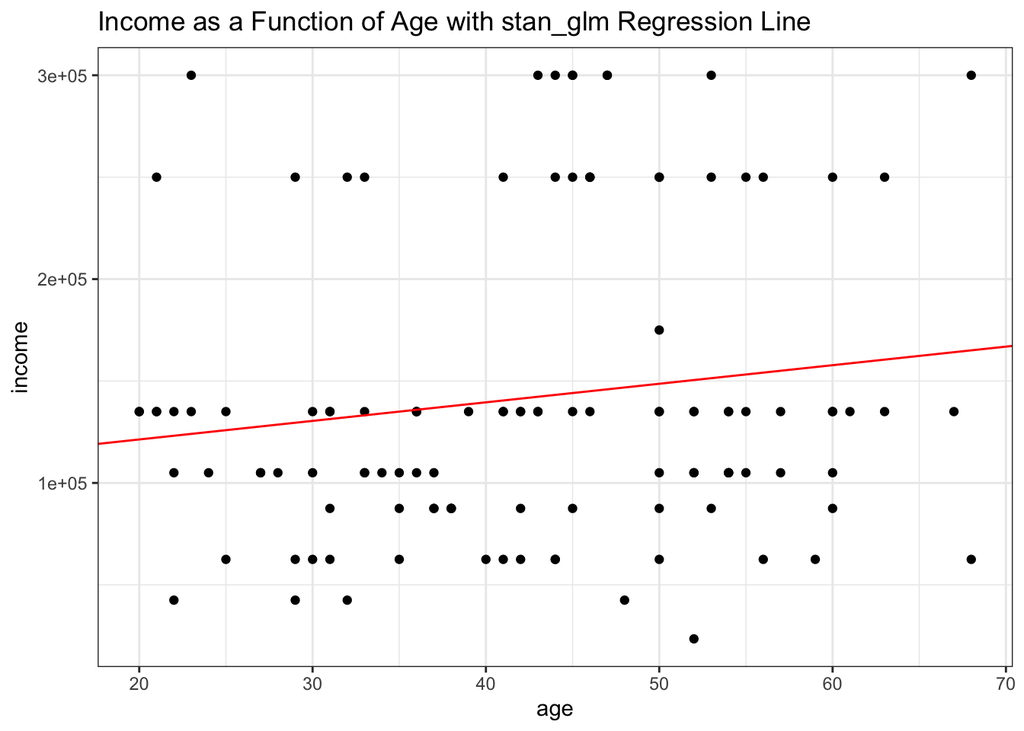